# Lab 4: Principal Component Analysis (PCA) and Linear Discriminant Analysis (LDA)

Makesh Srinivasan

3/6/2022

Registration number: 19BCE1717  
Faculty: Prof. Parvathi R  
Slot: L55 + L56  
Course code: CSE3020

## PCA LDA Lab exercise

##### Question

- Part 1: Use Breast Cancer Wisconsin data set from the UCI Machine learning repo to plot the PCA analysis. Use the ‘prcomp’ function runs PCA on the data.
  - You want to explain difference between malignant and benign tumors using Visualisation and add the response variable (diagnosis) to the plot
  - Construct some kind of model using the first 6 principal components to predict whether a tumor is benign or malignant and then compare it to a model using the original 30 variables.
- Part 2: Use the built-in iris dataset in R to plot the LDA analysis. Use the lda function of the MASS package in R Project the LDA visual output and Compare the LDA and PCA 2D Projection of Iris dataset

## Sections:

- Part 1: PCA & LDA using Breast Cancer Wisconsin data set from the UCI Machine learning repo
  - Visualisation of benign and malignant
  - Model to classify benign and malignant
- Part 2: IRIS dataset

#### PART 1

PCA & LDA using Breast Cancer Wisconsin data set from the UCI Machine learning repo

Load necessary libraries:

```r
library(dplyr)
library(MASS)
library(ROCR)
library(devtools)
# NOTE: I have imported other libraries as and when needed, theses are the ones I needed prior to performing the tasks
```

Load the dataset:

```r
data <- read.csv("lab5data.csv")
head(data)
```

```
##         id diagnosis radius_mean texture_mean perimeter_mean area_mean
## 1   842302         M       17.99        10.38         122.80    1001.0
## 2   842517         M       20.57        17.77         132.90    1326.0
## 3 84300903         M       19.69        21.25         130.00    1203.0
## 4 84348301         M       11.42        20.38          77.58     386.1
## 5 84358402         M       20.29        14.34         135.10    1297.0
## 6   843786         M       12.45        15.70          82.57     477.1
##   smoothness_mean compactness_mean concavity_mean concave_points_mean
## 1         0.11840          0.27760         0.3001             0.14710
## 2         0.08474          0.07864         0.0869             0.07017
## 3         0.10960          0.15990         0.1974             0.12790
## 4         0.14250          0.28390         0.2414             0.10520
## 5         0.10030          0.13280         0.1980             0.10430
## 6         0.12780          0.17000         0.1578             0.08089
##   symmetry_mean fractal_dimension_mean radius_se texture_se perimeter_se
```

[output cut: 34 more lines]

Run prcomp function and summarise the data:

```r
# Center and scale the data as well
data.pr <- prcomp(data[c(3:32)], center = TRUE, scale = TRUE)
summary(data.pr)
```

```
## Importance of components:
##                           PC1    PC2     PC3     PC4     PC5     PC6     PC7
## Standard deviation     3.6444 2.3857 1.67867 1.40735 1.28403 1.09880 0.82172
## Proportion of Variance 0.4427 0.1897 0.09393 0.06602 0.05496 0.04025 0.02251
## Cumulative Proportion  0.4427 0.6324 0.72636 0.79239 0.84734 0.88759 0.91010
##                            PC8    PC9    PC10   PC11    PC12    PC13    PC14
## Standard deviation     0.69037 0.6457 0.59219 0.5421 0.51104 0.49128 0.39624
## Proportion of Variance 0.01589 0.0139 0.01169 0.0098 0.00871 0.00805 0.00523
## Cumulative Proportion  0.92598 0.9399 0.95157 0.9614 0.97007 0.97812 0.98335
##                           PC15    PC16    PC17    PC18    PC19    PC20   PC21
## Standard deviation     0.30681 0.28260 0.24372 0.22939 0.22244 0.17652 0.1731
## Proportion of Variance 0.00314 0.00266 0.00198 0.00175 0.00165 0.00104 0.0010
## Cumulative Proportion  0.98649 0.98915 0.99113 0.99288 0.99453 0.99557 0.9966
##                           PC22    PC23   PC24    PC25    PC26    PC27    PC28
## Standard deviation     0.16565 0.15602 0.1344 0.12442 0.09043 0.08307 0.03987
## Proportion of Variance 0.00091 0.00081 0.0006 0.00052 0.00027 0.00023 0.00005
## Cumulative Proportion  0.99749 0.99830 0.9989 0.99942 0.99969 0.99992 0.99997
##                           PC29    PC30
## Standard deviation     0.02736 0.01153
## Proportion of Variance 0.00002 0.00000
## Cumulative Proportion  1.00000 1.00000
```

The data is now standardised

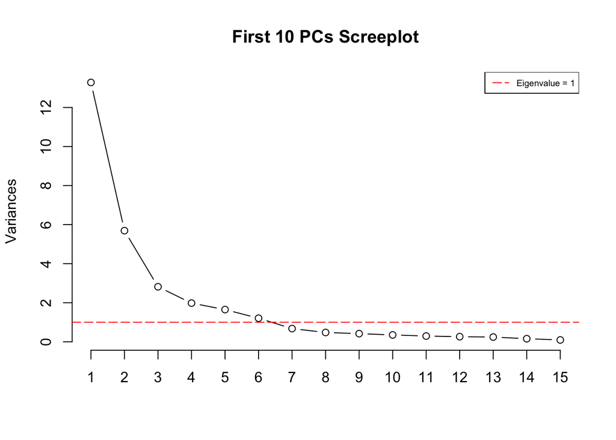

```r
screeplot(data.pr, type = "l", npcs = 15, main = "First 10 PCs Screeplot")
abline(h = 1, col="red", lty=5)
legend("topright", legend=c("Eigenvalue = 1"), col=c("red"), lty=5, cex=0.6)
```

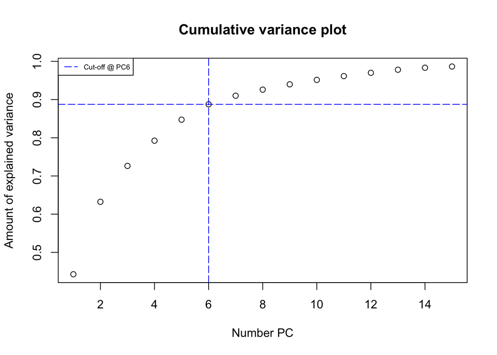

```r
cumpro <- cumsum(data.pr$sdev^2 / sum(data.pr$sdev^2))
plot(cumpro[0:15], xlab = "Number PC", ylab = "Amount of explained variance", main = "Cumulative variance plot")
abline(v = 6, col="blue", lty=5)
abline(h = 0.88759, col="blue", lty=5)
legend("topleft", legend=c("Cut-off @ PC6"), col=c("blue"), lty=5, cex=0.6)
```

**INFERENCE:** the first 6 components has an Eigenvalue > 1 and explains almost 90% of variance  
Hence, we can reduce the dimension from 30 to 6

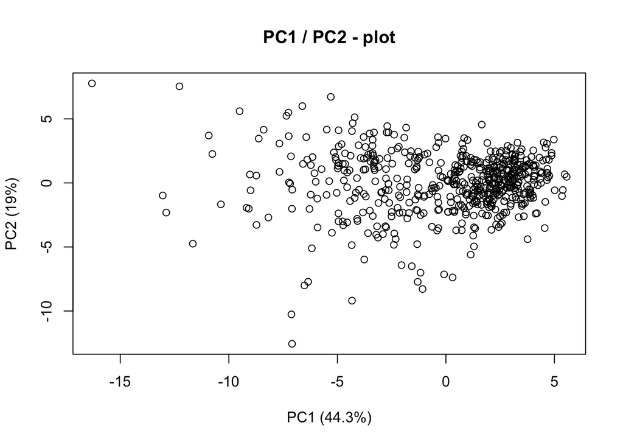

```r
plot(data.pr$x[,1],data.pr$x[,2], xlab="PC1 (44.3%)", ylab = "PC2 (19%)", main = "PC1 / PC2 - plot")
```

**INFERENCE:** Here, we observe the first two components that explain 60% of the total variance

```r
# visualisation library
library("factoextra")
```

#### Visualisation of benign and malignant

##### (i) You want to explain difference between malignant and benign tumors using Visualisation and add the response variable (diagnosis) to the plot

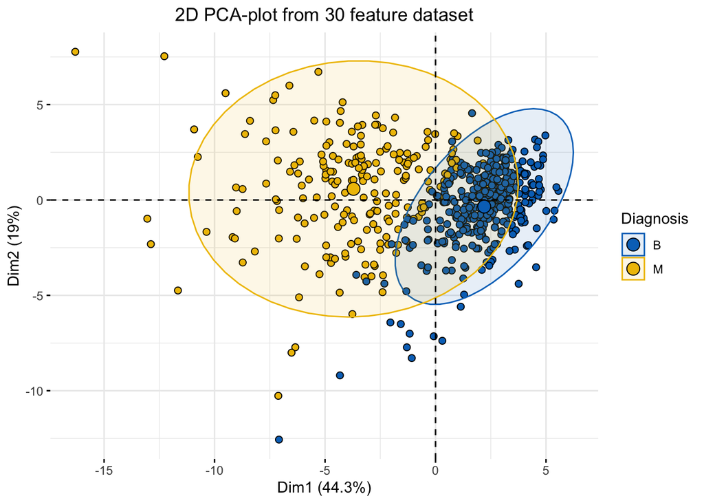

```r
fviz_pca_ind(data.pr, geom.ind = "point", pointshape = 21, pointsize = 2, fill.ind = data$diagnosis, col.ind = "black", palette = "jco", addEllipses = TRUE, label = "var", col.var = "black", repel = TRUE, legend.title = "Diagnosis") +
  ggtitle("2D PCA-plot from 30 feature dataset") +
  theme(plot.title = element_text(hjust = 0.5))
```

Check for missing values:

```r
data %>%
  summarise_all(funs(sum(is.na(.))))
```

```
##   id diagnosis radius_mean texture_mean perimeter_mean area_mean
## 1  0         0           0            0              0         0
##   smoothness_mean compactness_mean concavity_mean concave_points_mean
## 1               0                0              0                   0
##   symmetry_mean fractal_dimension_mean radius_se texture_se perimeter_se
## 1             0                      0         0          0            0
##   area_se smoothness_se compactness_se concavity_se concave_points_se
## 1       0             0              0            0                 0
##   symmetry_se fractal_dimension_se radius_worst texture_worst perimeter_worst
## 1           0                    0            0             0               0
##   area_worst smoothness_worst compactness_worst concavity_worst
## 1          0                0                 0               0
##   concave_points_worst symmetry_worst fractal_dimension_worst
## 1                    0              0                       0
```

#### Model to classify benign and malignant

##### (ii) Construct some kind of model using the first 6 principal components to predict whether a tumor is benign or malignant and then compare it to a model using the original 30 variables.

```r
# Conver the dataset into matix
data.data <- as.matrix(data[,c(3:32)])
row.names(data.data) <- data$id
data_raw <- cbind(data.data, as.numeric(as.factor(data$diagnosis))-1)
colnames(data_raw)[31] <- "diagnosis"

# 75/25 split of our data using the sample()
s_size_raw <- floor(0.75 * nrow(data_raw))
t_raw <- sample(nrow(data_raw), size = s_size_raw)
train_raw.data <- as.data.frame(data_raw[t_raw, ])
test_raw.data <- as.data.frame(data_raw[-t_raw, ])
f <- paste(names(train_raw.data)[31], "~", paste(names(train_raw.data)[-31], collapse=" + "))
data_raw.lda <- lda(as.formula(paste(f)), data = train_raw.data)

# Predictions
data_raw.lda.predict <- predict(data_raw.lda, newdata = test_raw.data)
data_raw.lda.predict$class
```

```
##   [1] 1 1 1 1 1 1 1 1 0 1 0 0 0 0 1 1 0 1 0 0 1 1 0 0 0 0 1 1 0 0 1 0 0 1 0 0 0
##  [38] 0 1 1 0 1 0 0 0 0 1 0 0 1 1 0 1 0 0 0 0 0 0 0 1 0 0 0 0 1 0 1 1 1 0 0 1 1
##  [75] 0 0 0 0 1 0 1 0 0 0 1 0 1 1 0 0 1 0 1 0 1 0 0 1 0 0 0 0 0 0 0 0 1 1 0 0 1
## [112] 0 0 1 1 0 0 0 0 0 0 0 0 0 0 0 0 1 0 0 1 0 0 1 1 0 0 0 0 0 0 0 1
## Levels: 0 1
```

```r
data_raw.lda.predict$posterior
```

```
##                     0            1
## 844359   4.456392e-03 9.955436e-01
## 845636   4.121699e-01 5.878301e-01
## 84610002 4.170768e-04 9.995829e-01
## 848406   8.011387e-03 9.919886e-01
## 852631   1.226600e-06 9.999988e-01
## 852763   3.282434e-04 9.996718e-01
## 854039   1.666975e-04 9.998333e-01
## 854268   1.408125e-01 8.591875e-01
## 855138   6.825036e-01 3.174964e-01
## 855625   1.546660e-06 9.999985e-01
## 857374   9.997315e-01 2.685272e-04
## 857438   5.540640e-01 4.459360e-01
## 858477   9.999945e-01 5.543620e-06
## 859711   9.999994e-01 6.195107e-07
```

[output cut: 129 more lines]

```r
data_raw.lda.predict.posteriors <-as.data.frame(data_raw.lda.predict$posterior)
data_raw.lda.predict.posteriors
```

```
##                     0            1
## 844359   4.456392e-03 9.955436e-01
## 845636   4.121699e-01 5.878301e-01
## 84610002 4.170768e-04 9.995829e-01
## 848406   8.011387e-03 9.919886e-01
## 852631   1.226600e-06 9.999988e-01
## 852763   3.282434e-04 9.996718e-01
## 854039   1.666975e-04 9.998333e-01
## 854268   1.408125e-01 8.591875e-01
## 855138   6.825036e-01 3.174964e-01
## 855625   1.546660e-06 9.999985e-01
## 857374   9.997315e-01 2.685272e-04
## 857438   5.540640e-01 4.459360e-01
## 858477   9.999945e-01 5.543620e-06
## 859711   9.999994e-01 6.195107e-07
```

[output cut: 129 more lines]

Evaluation of the model

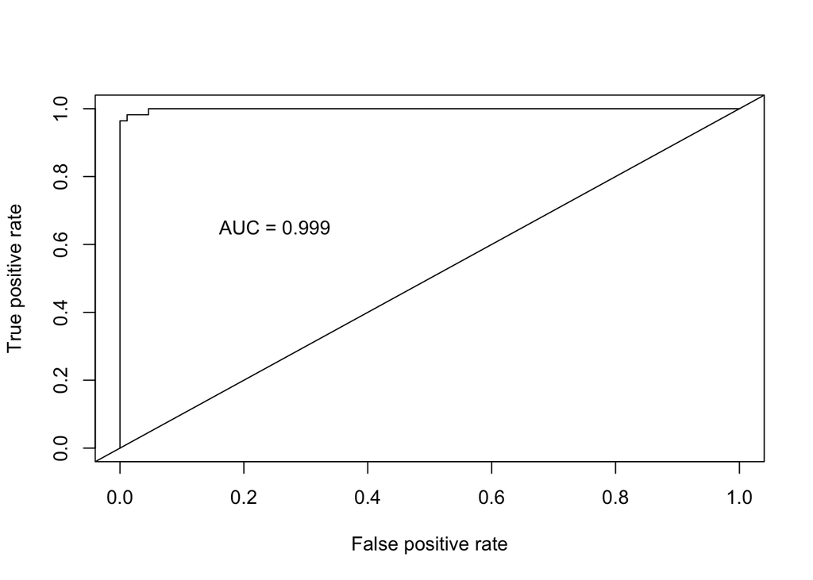

```r
pred <- prediction(data_raw.lda.predict.posteriors[,2], test_raw.data$diagnosis)
roc.perf = performance(pred, measure = "tpr", x.measure = "fpr")
auc.train <- performance(pred, measure = "auc")
auc.train <- auc.train@y.values
plot(roc.perf)
abline(a=0, b= 1)
text(x = .25, y = .65 ,paste("AUC = ", round(auc.train[[1]],3), sep = ""))
```

```r
data.pcst <- data.pr$x[,1:6]
data.pcst <- cbind(data.pcst, as.numeric(as.factor(data$diagnosis))-1)
colnames(data.pcst)[7] <- "diagnosis"
colnames(data.pcst)
```

```
## [1] "PC1"       "PC2"       "PC3"       "PC4"       "PC5"       "PC6"
## [7] "diagnosis"
```

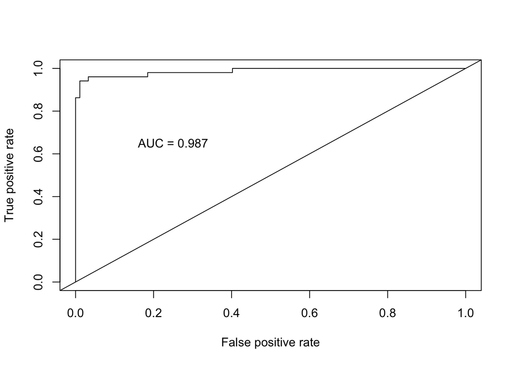

```r
smp_size <- floor(0.75 * nrow(data.pcst))
train_ind <- sample(nrow(data.pcst), size = smp_size)
train_raw2.data <- as.data.frame(data.pcst[train_ind, ])
test_raw2.data <- as.data.frame(data.pcst[-train_ind, ])
data.lda <- lda(diagnosis ~ PC1 + PC2 + PC3 + PC4 + PC5 + PC6, data = train_raw2.data)
data.lda.predict <- predict(data.lda, newdata = test_raw2.data)
f2 <- paste(names(train_raw2.data)[7], "~", paste(names(train_raw2.data)[-7], collapse=" + "))
data_raw.lda2 <- lda(as.formula(paste(f2)), data = train_raw2.data)
data_raw.lda.predict2 <- predict(data_raw.lda2, newdata = test_raw2.data)
data_raw.lda.predict.posteriors2 <- as.data.frame(data_raw.lda.predict2$posterior)
pred2 <- prediction(data_raw.lda.predict.posteriors2[,2], test_raw2.data$diagnosis)
roc.perf2 = performance(pred2, measure = "tpr", x.measure = "fpr")
auc.train2 <- performance(pred2, measure = "auc")
auc.train2 <- auc.train2@y.values
# Plot
plot(roc.perf2)
abline(a=0, b= 1)
text(x = .25, y = .65 ,paste("AUC = ", round(auc.train2[[1]],3), sep = ""))
```

```r
data.pcst <- data.pr$x[,1:6]
data.pcst <- cbind(data.pcst, as.numeric(as.factor(data$diagnosis))-1)
colnames(data.pcst)[7] <- "diagnosis"
smp_size <- floor(0.75 * nrow(data.pcst))
train_ind <- sample(nrow(data.pcst), size = smp_size)
train.data <- as.data.frame(data.pcst[train_ind, ])
test.data <- as.data.frame(data.pcst[-train_ind, ])
data.lda <- lda(diagnosis ~ PC1 + PC2 + PC3 + PC4 + PC5 + PC6, data = train.data)
data.lda.predict <- predict(data.lda, newdata = test.data)
```

#### PART 2

Use the built-in iris dataset in R to plot the LDA analysis. Use the lda function of the MASS package in R  
Project the LDA visual output and Compare the LDA and PCA 2D Projection of Iris dataset

```r
data(iris)
head(iris)
```

```
##   Sepal.Length Sepal.Width Petal.Length Petal.Width Species
## 1          5.1         3.5          1.4         0.2  setosa
## 2          4.9         3.0          1.4         0.2  setosa
## 3          4.7         3.2          1.3         0.2  setosa
## 4          4.6         3.1          1.5         0.2  setosa
## 5          5.0         3.6          1.4         0.2  setosa
## 6          5.4         3.9          1.7         0.4  setosa
```

```r
require(MASS)
require(ggplot2)
require(scales)
 pca <- prcomp(iris[,-5],
              center = TRUE,
              scale. = TRUE)
prop.pca = pca$sdev^2/sum(pca$sdev^2)
lda <- lda(Species ~ .,
           iris,
           prior = c(1,1,1)/3)
r <- lda(formula = Species ~ .,
         data = iris,
         prior = c(1,1,1)/3)
prop.lda = r$svd^2/sum(r$svd^2)
plda <- predict(object = lda,
                newdata = iris)
dataset = data.frame(species = iris[,"Species"],
                     pca = pca$x, lda = plda$x)
```

Plotting LDA:

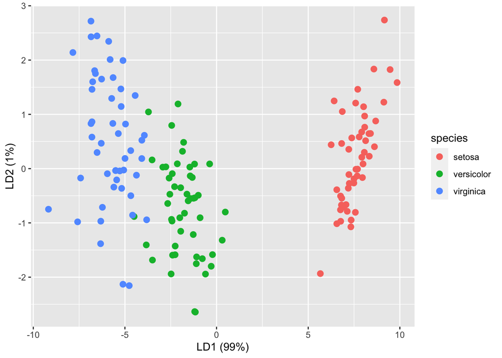

```r
ggplot(dataset) + geom_point(aes(lda.LD1, lda.LD2, colour = species,), size = 2.5) + labs(x = paste("LD1 (", percent(prop.lda[1]), ")", sep=""), y = paste("LD2 (", percent(prop.lda[2]), ")", sep=""))
```

Plotting PCA

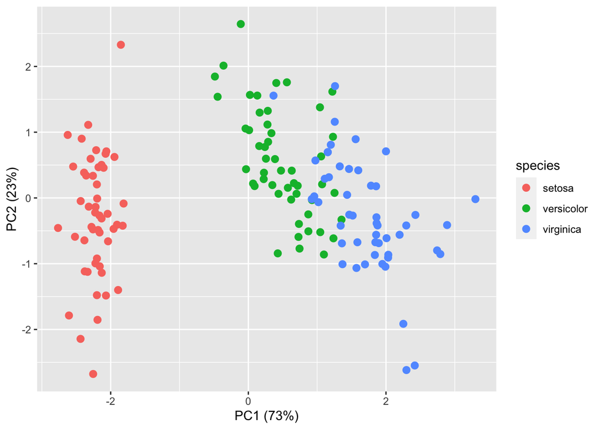

```r
ggplot(dataset) + geom_point(aes(pca.PC1, pca.PC2, colour = species), size = 2.5) + labs(x = paste("PC1 (", percent(prop.pca[1]), ")", sep=""), y = paste("PC2 (", percent(prop.pca[2]), ")", sep=""))
```